# Shots, Shots, Shots: An Analysis of Studies of COVID-19 Vaccines in the NCBI Database

Xiaotang (Jeffrey) Zhou

13/03/2022

## APIs

To start, we will find the number of papers containing the term “sars-cov-2 vaccine” in the NCBI database using the code covered in a previous lab:

```
## [1] "20,866"
```

```r
table(!is.na(titles))
```

```
##
## FALSE  TRUE
##     3   247
```

```r
table(!is.na(journals))
```

```
##
## TRUE
##  250
```

```r
table(!is.na(abstracts))
```

```
##
## FALSE  TRUE
##    31   219
```

```r
table(!is.na(pub_year))
```

```
##
## FALSE  TRUE
##     4   246
```

```r
table(!is.na(pub_month))
```

```
##
## FALSE  TRUE
##    36   214
```

```r
table(!is.na(pub_day))
```

```
##
## FALSE  TRUE
##    72   178
```

Now that we have all the information we need, we can proceed to constructing the dataset containing each paper’s PubMed ID, title, journal to which it was published, publication date (split into year, month, and date to account for missing values in each), and abstract:

Information about the 250 papers extracted from the NCBI database

| PubMedID | Title | Journal | Publication Year | Publication Month | Publication Day | Abstract |
| --- | --- | --- | --- | --- | --- | --- |
| 35452692 | A third dose of the BNT162b2 mRNA vaccine significantly improves immune responses among liver transplant recipients. | Journal of hepatology | 2022 | Apr | 19 | Immune responses of solid organ transplant recipients to two doses of the BNT162b2 mRNA anti-SARS-CoV-2 vaccine is impaired. The immunogenicity and safety of a third dose among liver transplant (LT) r… |
| 35452552 | COVID-19 Disease and Vaccination in Pregnant and Lactating Women. | American journal of reproductive immunology (New York, N.Y. : 1989) | 2022 | Apr | 22 | More than 325,000 cases of coronavirus disease 2019 (COVID-19) have been reported among pregnant women in the Americas. Multiple studies indicate that pregnant women are more susceptible to adverse CO… |
| 35452357 | Self-Reported adverse events among Chinese healthcare workers immunized with COVID-19 vaccines composed of inactivated SARS-CoV-2. | Human vaccines &amp; immunotherapeutics | 2022 | Apr | 22 | Mass vaccination is critical to control the pandemic of coronavirus disease 2019 (COVID-19). Fear of adverse events (AEs) after COVID-19 vaccination is a main factor associated with vaccination hesita… |
| 35452345 | Intention to vaccinate young children against COVID-19: a large-scale survey of Hong Kong parents. | Human vaccines &amp; immunotherapeutics | 2022 | Apr | 22 | COVID-19 vaccines (Sinovac and Pfizer/BioNTech) have recently been approved for Hong Kong children. Understanding parental intentions to vaccinate children against COVID-19 is important to the develop… |
| 35451839 | Smart Mushroom-Inspired Imprintable and Lightly Detachable (MILD) Microneedle Patterns for Effective COVID-19 Vaccination and Decentralized Information Storage. | ACS nano | 2022 | Apr | 22 | The key to controlling the spread of the coronavirus disease 2019 (COVID-19) and reducing mortality is highly dependent on the safe and effective use of vaccines for the general population. Current CO… |
| 35451644 | COVID-19 vaccine acceptance and perceptions among dental teaching staff of a governmental university in Egypt. | The Journal of the Egyptian Public Health Association | 2022 | Apr | 21 | Vaccine acceptance among healthcare workers (HCWs) is an important determinant of its acceptance among the general population. Dentists are an essential group of HCWs who are at an increased risk of C… |
| 35451341 | Animal models for studying covid-19, prevention, and therapy: Pathology and disease phenotypes. | Veterinary pathology | 2022 | Apr | 22 | Translational models have played an important role in the rapid development of safe and effective vaccines and therapeutic agents for the ongoing coronavirus disease 2019 (COVID-19) pandemic caused by… |
| 35451293 | Vaccine-Inducted Thrombotic Thrombocytopenia and Covid-19 Vaccines: Case Series. | Prilozi (Makedonska akademija na naukite i umetnostite. Oddelenie za medicinski nauki) | 2022 | Apr | 22 | Vaccine-induced thrombotic thrombocytopenia (VITT) is a condition similar to heparin-induced thrombocytopenia (HIT), but it is associated with prior administration of COVID-19 vaccines without prior e… |
| 35448837 | Cubital Tunnel Syndrome Temporally after COVID-19 Vaccination. | Tropical medicine and infectious disease | 2022 | Apr | 16 | Coronavirus disease 2019 (COVID-19) is the most dramatic pandemic of the new millennium. To counter it, specific vaccines have been launched in record time under emergency use authorization or conditi… |
| 35447596 | Measurements of SARS-CoV-2 antibody dissociation rate constant by chaotrope-free biolayer interferometry in serum of COVID-19 convalescent patients. | Biosensors &amp; bioelectronics | 2022 | Apr | 09 | Kinetics measurements of antigen-antibody binding interactions are critical to understanding the functional efficiency of SARS-CoV-2 antibodies. Previously reported chaotrope-based avidity assays that… |
| 35447423 | Identifying environmental factors that influence immune response to SARS-CoV-2: Systematic evidence map protocol. | Environment international | 2022 | Apr | 08 | Widespread environmental contamination can directly interact with human immune system functions. Environmental effects on the immune system may influence human susceptibility to respiratory infections… |
| 35447123 | Increasing Coronavirus Disease 2019 Vaccine Uptake in Pediatric Primary Care by Offering Vaccine to Household Members. | The Journal of pediatrics | 2022 | Apr | 18 | Pediatric primary care is a trusted source for treatment and information. In the 6 months after COVID-19 vaccines became available for adolescents, we administered 2,286 doses (1,270 to patients; 1,01… |
| 35446945 | Frailty and COVID-19 mRNA Vaccine Antibody Response in The COVID-19 Community Research Partnership. | The journals of gerontology. Series A, Biological sciences and medical sciences | 2022 | Apr | 21 | COVID-19 has disproportionately affected older adults. Frailty has been associated with impaired vaccine response in other vaccine types, but the impact of frailty on mRNA vaccine response is undefine… |
| 35446828 | Vaccination Coverage with Selected Vaccines and Exemption Rates Among Children in Kindergarten - United States, 2020-21 School Year. | MMWR. Morbidity and mortality weekly report | 2022 | Apr | 22 | State and local school vaccination requirements serve to protect students against vaccine-preventable diseases (1). This report summarizes data collected for the 2020-21 school year by state and local… |
| 35446827 | Hospitalizations of Children Aged 5-11 Years with Laboratory-Confirmed COVID-19 - COVID-NET, 14 States, March 2020-February 2022. | MMWR. Morbidity and mortality weekly report | 2022 | Apr | 22 | On October 29, 2021, the Food and Drug Administration expanded the Emergency Use Authorization for Pfizer-BioNTech COVID-19 vaccine to children aged 5-11 years; CDC’s Advisory Committee on Immunizatio… |
| 35446781 | Monitoring user opinions and side effects on COVID-19 vaccines in the Twittersphere: Infodemiology Study of Tweets. | Journal of medical Internet research | 2022 | Mar | 09 | In the current phase of the COVID-19 pandemic, we are witnessing the most massive vaccine rollout in human history. Like any other drug, vaccines may cause unexpected side effects, which need to be ti… |
| 35446373 | De novo and relapsed immune thrombocytopenia after COVID-19 vaccines: results of French safety monitoring. | Blood | 2022 | Apr | 21 | NA |
| 35446353 | Evaluation of the Durability of the Immune Humoral Response to COVID-19 Vaccines in Patients With Cancer Undergoing Treatment or Who Received a Stem Cell Transplant. | JAMA oncology | 2022 | Apr | 21 | The durability of the antibody response to COVID-19 vaccines in patients with cancer undergoing treatment or who received a stem cell transplant is unknown and may be associated with infection outcome… |
| 35445433 | Clinical care of children and adolescents with COVID-19: recommendations from the National COVID-19 Clinical Evidence Taskforce. | The Medical journal of Australia | 2022 | Apr | 21 | NA |
| 35445269 | Reliably Assessing Duration of Protection for COVID-19 Vaccines. | The Journal of infectious diseases | 2022 | Apr | 21 | Decision-making about vaccination and boosting schedules for COVID-19 hinges on reliable methods for evaluating the longevity of vaccine protection. We show that modeling of protection as a piecewise … |
| 35444978 | Parents’ Perspectives Toward School Reopening During COVID-19 Pandemic in Indonesia-A National Survey. | Frontiers in public health | 2022 | NA | NA | All sectors are affected due to COVID-19 pandemic occurring worldwide, including the education industry. School closure had been taking place for more than a year in Indonesia. Despite the controversi… |
| 35444866 | Not All That Is Droopy Post Ad26.COV2.S (JNJ) Vaccine Is Bell’s Palsy: A Rare Case of Isolated Dorsal Pontine Stroke Causing Ipsilateral Complete Hemi-Facial Palsy. | Cureus | 2022 | Mar | NA | The Ad26.COV2.S vaccine, developed by Janssen (Beerse, Belgium), the pharmaceutical wing of Johnson &amp; Johnson (JNJ), is one of the three vaccines approved for use against coronavirus disease 2019 … |
| 35444813 | Knowledge and Willingness to Accept Vaccine Against SARS-CoV-2 Among Undergraduate Medical Students in Delhi, India. | Current health sciences journal | NA | NA | NA | Vaccination against severe acute respiratory syndrome coronavirus-2 (SARS-CoV-2) is the most desired solution to combat COVID-19. Understanding the willingness to accept vaccines is essential to make … |
| 35444667 | Vaccine-Associated Enhanced Disease and Pathogenic Human Coronaviruses. | Frontiers in immunology | 2022 | NA | NA | Vaccine-associated enhanced disease (VAED) is a difficult phenomenon to define and can be confused with vaccine failure. Using studies on respiratory syncytial virus (RSV) vaccination and dengue virus… |
| 35444664 | Conservation and Evolution of Antigenic Determinants of SARS-CoV-2: An Insight for Immune Escape and Vaccine Design. | Frontiers in immunology | 2022 | NA | NA | Coronavirus disease 2019 (COVID-19) is the most devastating pandemic of the century, which is still far from over. The remarkable success of severe acute respiratory syndrome coronavirus 2 (SARS-CoV-2… |
| 35444662 | Inflammation in Cerebral Venous Thrombosis. | Frontiers in immunology | 2022 | NA | NA | Cerebral venous thrombosis (CVT) is a rare form of cerebrovascular disease that impairs people’s wellbeing and quality of life. Inflammation is considered to play an important role in CVT initiation a… |
| 35444478 | Acceptance of COVID-19 Vaccine Among High-Risk Occupations in a Port City of China and Multifaceted Strategies for Increasing Vaccination Coverage: A Cross-Sectional Study. | Risk management and healthcare policy | 2022 | NA | NA | Considering high risk of imported epidemic in port cities, it is necessary to estimate COVID-19 vaccine acceptability and to promote vaccination coverage of high-risk occupations. A cross-sectional su… |
| 35444328 | COVID’s diabetes risk, vaccine rankings and hidden industry ties. | Nature | 2022 | Apr | NA | NA |
| 35444221 | Cross-reactive antibodies elicited to conserved epitopes on SARS-CoV-2 spike protein after infection and vaccination. | Scientific reports | 2022 | Apr | 20 | SARS-CoV-2 is a novel betacoronavirus that caused coronavirus disease 2019 and has resulted in millions of deaths worldwide. Novel coronavirus infections in humans have steadily become more common. Un… |
| 35443917 | Seroconversion panels demonstrate anti-SARS-CoV-2 antibody development after administration of the mRNA-1273 vaccine. | Vaccine | 2022 | Apr | 08 | Seroconversion panels are an important tool for investigating antibody responses in acute and chronic phases of disease and development of serological assays for viral diseases including COVID-19. Glo… |

[output cut: 220 more lines]

## Text Mining

Now, we can shift our attention to text mining by first loading in the `pubmed.csv` data from the class GitHub repository. Then, we can tokenize each abstract and visualize the top 10 tokens in both tabular and graphical form below:

The Frequencies of the Top 10 Most Common Words in the PubMed Data

| Word | Frequency |
| --- | --- |
| the | 28126 |
| of | 24760 |
| and | 19993 |
| in | 14653 |
| to | 10920 |
| a | 8245 |
| with | 8038 |
| covid | 7275 |
| 19 | 7080 |
| is | 5649 |

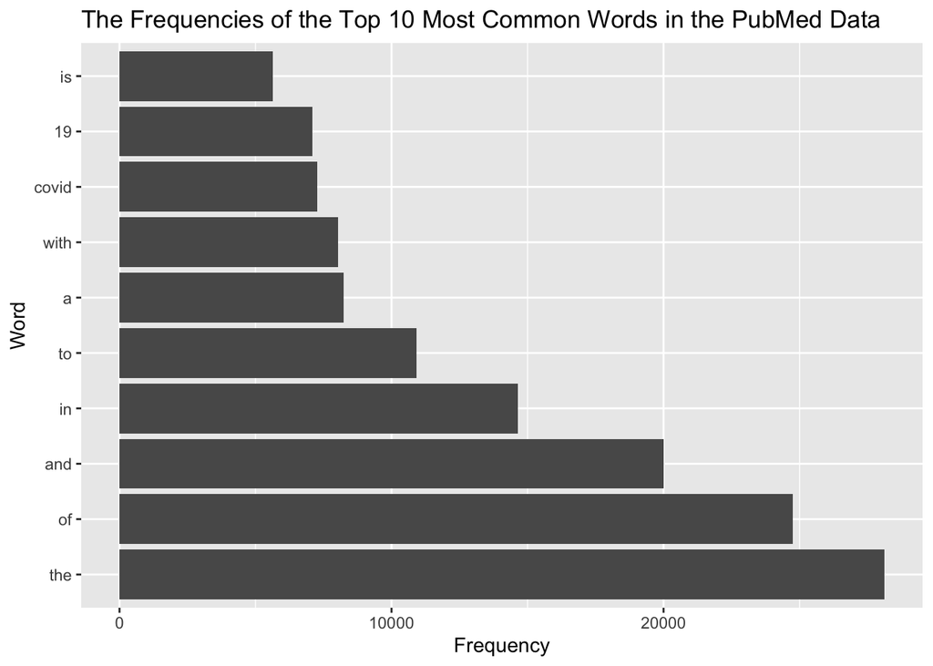

As we can see, the top 10 tokens aren’t very interesting as they are all just regularly used English words with the exception of “covid” and “19”, so our next step is to remove all of these stopwords. The following table shows the top 5 tokens after removing stopwords for each of the search terms:

The Frequencies of the Top 5 Most Common Words Corresponding to the 5 Search Terms in the PubMed Data

| Search Term | Word | Frequency |
| --- | --- | --- |
| covid | covid | 7275 |
| covid | 19 | 7035 |
| covid | patients | 2293 |
| covid | disease | 943 |
| covid | pandemic | 800 |
| cystic fibrosis | fibrosis | 867 |
| cystic fibrosis | cystic | 862 |
| cystic fibrosis | cf | 625 |
| cystic fibrosis | patients | 586 |
| cystic fibrosis | disease | 400 |
| meningitis | patients | 446 |
| meningitis | meningitis | 429 |
| meningitis | meningeal | 219 |
| meningitis | csf | 206 |
| meningitis | clinical | 187 |
| preeclampsia | pre | 2038 |
| preeclampsia | eclampsia | 2005 |
| preeclampsia | preeclampsia | 1863 |
| preeclampsia | women | 1196 |
| preeclampsia | pregnancy | 969 |
| prostate cancer | cancer | 3840 |
| prostate cancer | prostate | 3832 |
| prostate cancer | patients | 934 |
| prostate cancer | treatment | 926 |
| prostate cancer | disease | 652 |

Next, we can look at the most common pairs of words among the abstracts in the data. The following table and barplot visualize the top 10 bigrams:

The Frequencies of the Top 10 Most Common Bigrams in the PubMed Data After Removing Stopwords

| Bigram | First Word | Second Word | Frequency |
| --- | --- | --- | --- |
| covid 19 | covid | 19 | 6969 |
| prostate cancer | prostate | cancer | 3222 |
| pre eclampsia | pre | eclampsia | 1854 |
| cystic fibrosis | cystic | fibrosis | 860 |
| 19 patients | 19 | patients | 447 |
| 19 pandemic | 19 | pandemic | 419 |
| coronavirus disease | coronavirus | disease | 361 |
| 95 ci | 95 | ci | 322 |
| sars cov | sars | cov | 317 |
| cov 2 | cov | 2 | 299 |

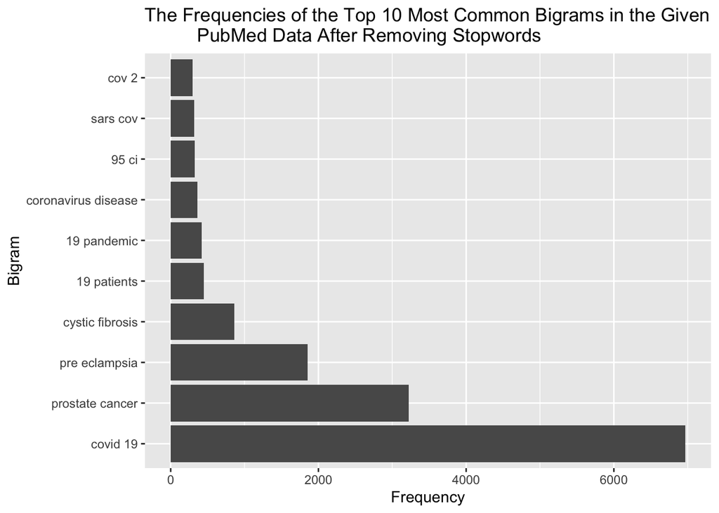

The 5 Largest TF-IDF Values For Words Corresponding to the 5 Search Terms in the PubMed Data

| Search Term | Word | TF-IDF Value |
| --- | --- | --- |
| covid | covid | 0.1041177 |
| covid | pandemic | 0.0114494 |
| covid | 19 | 0.0000000 |
| covid | disease | 0.0000000 |
| covid | patients | 0.0000000 |
| cystic fibrosis | cf | 0.0214528 |
| cystic fibrosis | fibrosis | 0.0165906 |
| cystic fibrosis | cystic | 0.0164949 |
| cystic fibrosis | disease | 0.0000000 |
| cystic fibrosis | patients | 0.0000000 |
| meningitis | meningitis | 0.0263883 |
| meningitis | meningeal | 0.0134709 |
| meningitis | csf | 0.0072141 |
| meningitis | clinical | 0.0000000 |
| meningitis | patients | 0.0000000 |
| preeclampsia | eclampsia | 0.0410837 |
| preeclampsia | preeclampsia | 0.0381741 |
| preeclampsia | pregnancy | 0.0063020 |
| preeclampsia | pre | 0.0000000 |
| preeclampsia | women | 0.0000000 |
| prostate cancer | prostate | 0.0906033 |
| prostate cancer | cancer | 0.0000000 |
| prostate cancer | disease | 0.0000000 |
| prostate cancer | patients | 0.0000000 |
| prostate cancer | treatment | 0.0000000 |

We can see in the table above which words (after removing stopwords, of course) have the highest TF-IDF values for each of the 5 search terms in the PubMed dataset. By comparing these words with the words with the highest frequencies for each search term, we can see that the words with the highest frequencies for each search term match exactly with the words with the highest TF-IDF values for each search term.

This may seem counterintuitive as TF-IDF values are generally understood to be larger for rare words and smaller for more common words, but upon closer inspection, this contrast can be explained by the fact that TF-IDF values can also be understood as a balancing measure with regards to whether a word is rare or common. As some words for some search terms can intuitively be seen as making up a massive proportion of all the words present for that search term (for example, take the word “covid” with the “covid” search term, it is natural for this word to make up the bulk of the words in abstracts under the “covid” search term), it is possible that these words are so overrepresented that their TF-IDF values get pushed upward, as the balancing measure is just skewed in the direction of having a larger frequency instead of a smaller frequency.